# Regression

February 14, 2022

# Regression

- In all the bivariate statistics so far, we described how variables move together.
- But, we have not used those variables as a system.
- where we have one
  - DV (dependent variable); and
  - IV (independent variable)

# Motivating Smoking and Lung Capacity

If you recall, we previously used data on smoking and lung capacity.

| cigarettes | lung_capacity |
| --- | --- |
| 0 | 45 |
| 5 | 42 |
| 10 | 33 |
| 15 | 31 |
| 20 | 29 |

When we plot these data, we found a negative linear association.

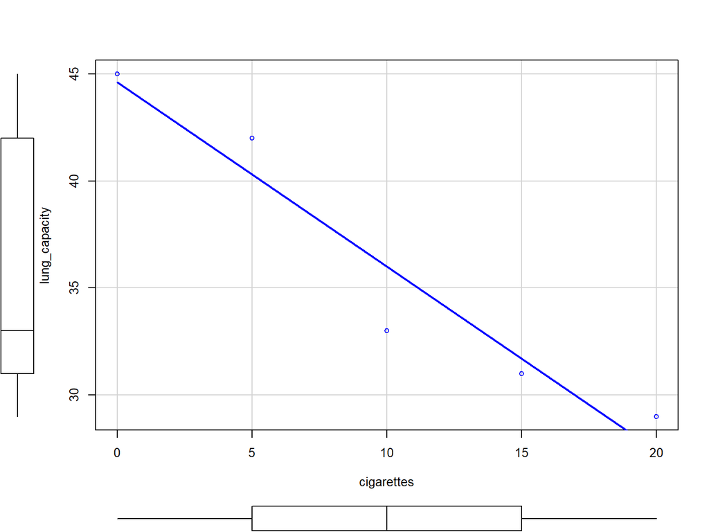

- Further, we found that the correlation between lung capacity and cigarette consumption was -0.962.
- This correlation suggests that 92.4 % of the variation in lung capacity can be explained by cigarette consumption.
- This high percentage means that when we know how many cigarettes someone consumes, we can predict lung capcity.
- The higher the correlation (and by extension, variance explained) the more accurate our predictions *ought* to be.

# Regression

- In simple language, we draw a line through the points in a scatter plot
- In more sophisicated language, we fit a linear model of the relationship between $x$ and $y$
- A regression line is a straight line that describes how a response variable $y$ changes as an explanatory variable $x$ changes.
- We often use a regression line to predict the value of $y$ for a given value of $x$,
  - when we believe the relationship between $x$ and $y$ is linear.

# Regression Line

- We can describe this line in a familiar equation
- Suppose that $y$ is a response variable (plotted on the vertical axis) and $x$ is an explanatory variable (plotted on the horizontal axis).
- A straight line relating $x$ to $y$ has an equation of the form

$y = a + bx$; (or $y = mx + b$)

- In this equation,
- $b$ ($m$) is the slope
  - the amount by which $y$ changes when $x$ increases by one unit.
- The number $a$ ($b$) is the intercept
  - the value of $y$ when $x$ = 0.
- With those two points, any straight line can be defined
  - (with one exception lines parallel to the $y$ axis)
  - within the Cartesian plane.

# Plot Line with changing positive slopes

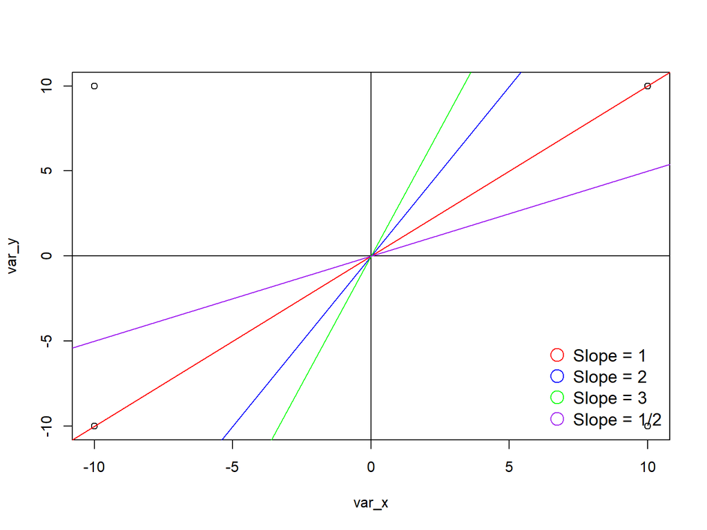

# Plot Line with changing negative slopes

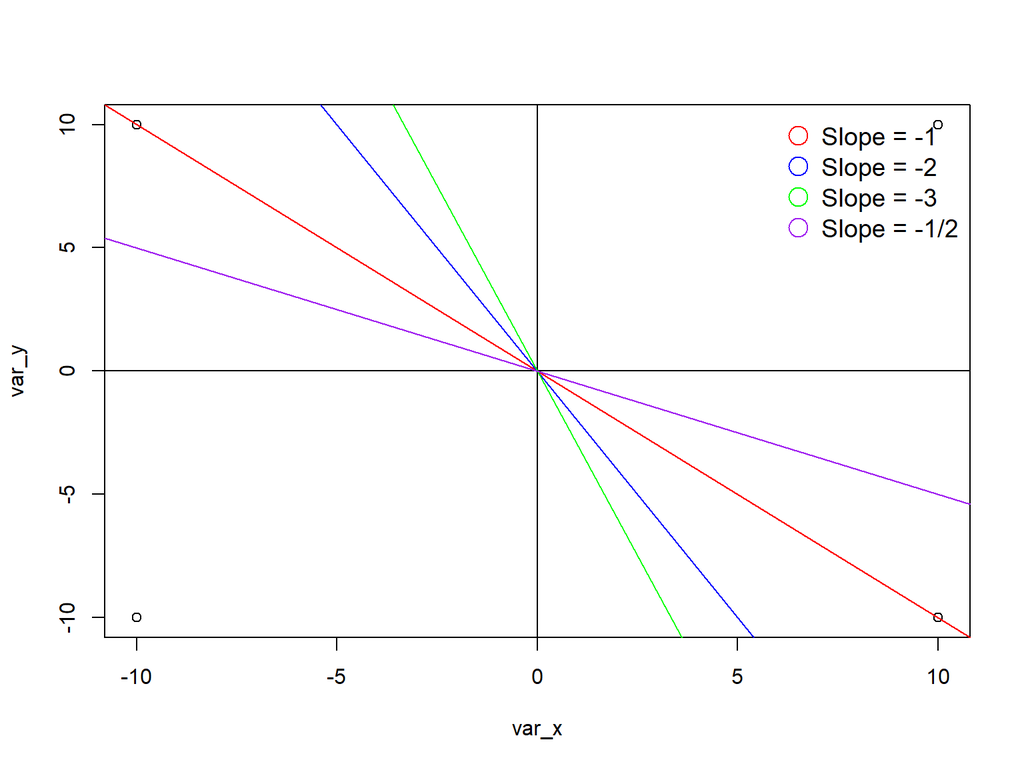

# Plot Line with changing positive intercepts

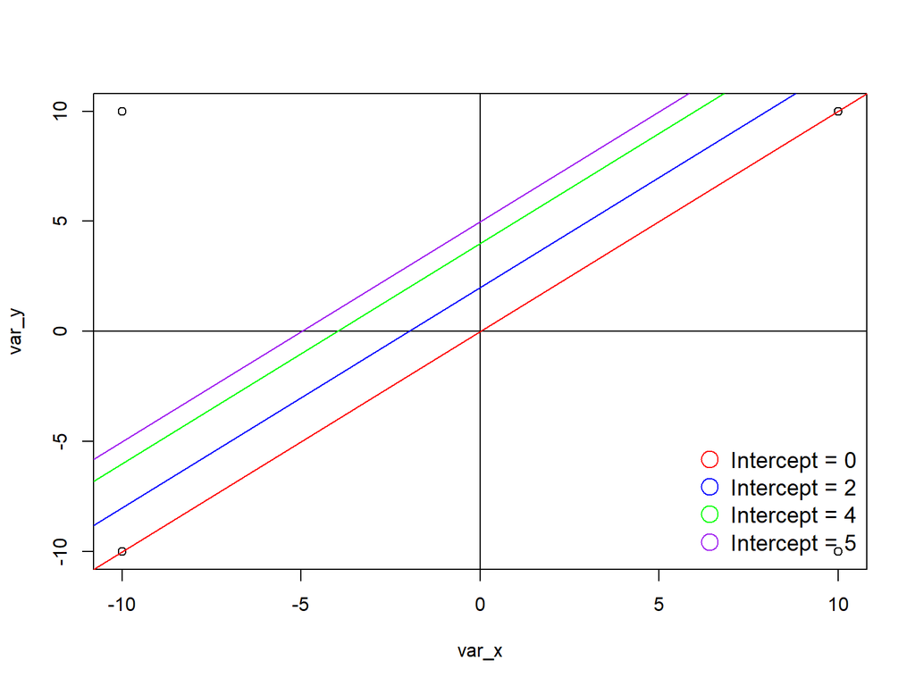

# Plot Line with changing negative intercepts

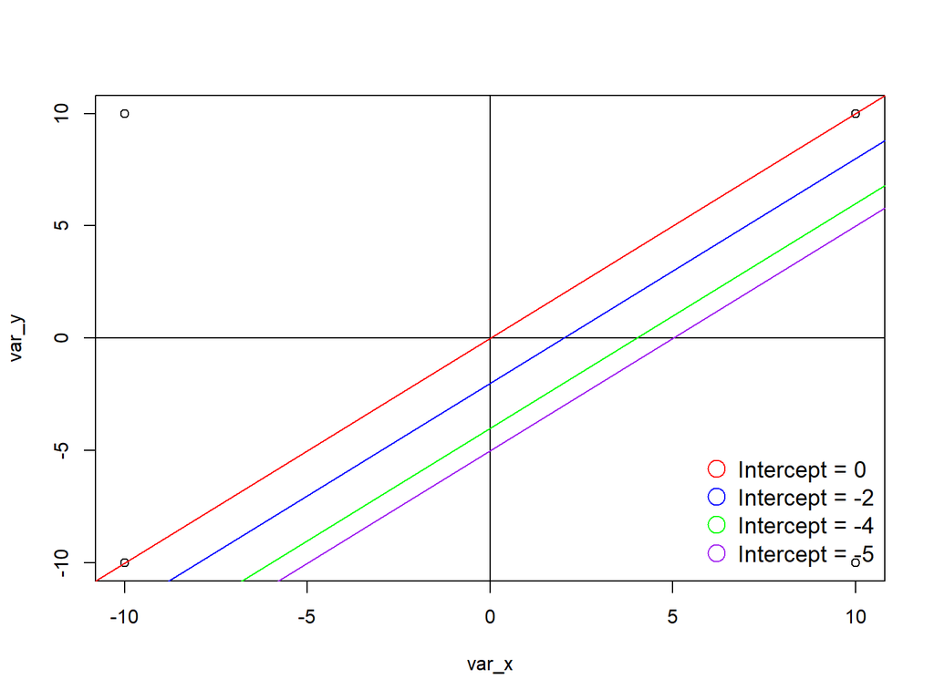

# Regression Line

- In order to eliminate subjectivity of creating a line to fit the data – we need an objective way to draw the line
- Indeed there are a variety of ways to create the line from the data.

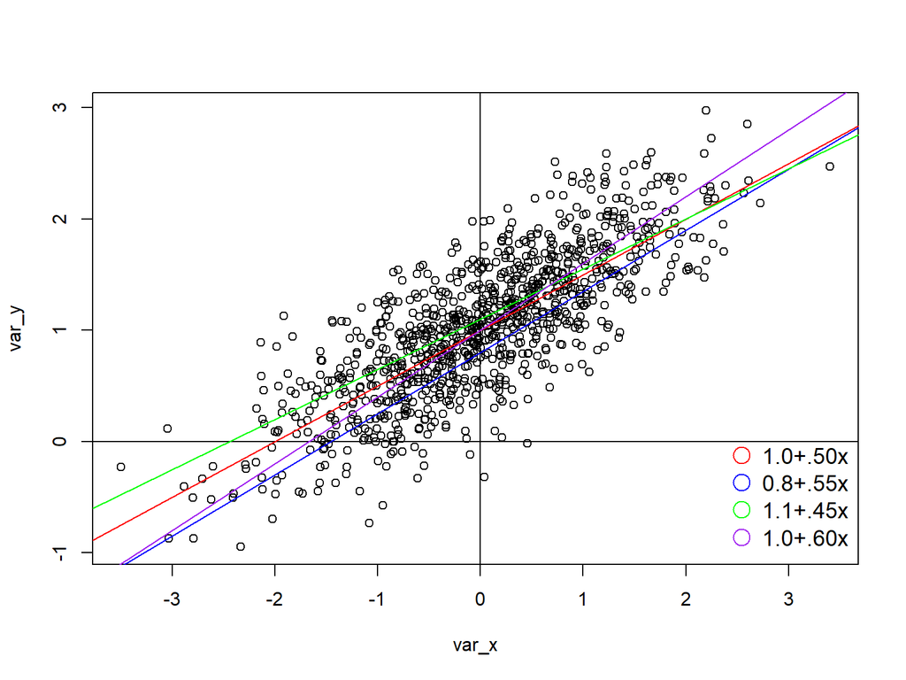

# Least Squares

- The most popular approach is the least-squares approach.
- The least-squares regression line of $y$ on $x$ is the line that makes
  - the sum of the squares of the vertical distances of the data points from the line as small as possible.
- The goal is to minimize the difference between actual and predicted values of the dependent variable $y$
  - min($\sum\limits^{n}_{i=1}(y_{i}-(a+bx_{i}))^{2}$)
  - min($\sum\limits^{n}_{i=1}(y_{i}-\widehat{y}_{i})^{2}$)
  - min($\sum\limits^{n}_{i=1}(e_{i})^{2}$)
- Sometimes the principle of least squares is described as minimizing the sum of the:
  - squares,
  - squared residuals, or
  - squared errors.

# Least Squares Equation

- We have data on an explanatory variable $x$ and a response variable $y$ for $n$ individuals.
- From the data, calculate the means $\bar{x}$ and $\bar{y}$
  - and the standard deviations $s_{x}$ and $s_{y}$ of the two variables and
  - their correlation r.
- The least-squares regression line is the line:

$\widehat{y}= a + bx$

- with slope:

$b=r \frac{s_{y}}{s_{x}}$

- and intercept:

$a=\bar{y}-b\bar{x}$

# Calculating the regression line: slope

- Using our smoking data, we can estimate the slope and intercept
- slope:
- $b=r \frac{s_{y}}{s_{x}}$
- $b=r_{lung capacity,cigarettes} \frac{s_{lung capacity}}{s_{cigarettes}}$
- -0.962* $\frac{7.071}{7.906}$
- -0.962* 0.894
- $b=$-0.86

# Calculating the regression line: intercept

- Using our smoking data, we can estimate the slope and intercept
- intercept:
- $a=\bar{y}-b\bar{x}$
- $a=\bar{lung capacity}-b\bar{cigarettes}$
- $a=\bar{lung capacity}-$-0.86$\bar{cigarettes}$
- $a=$ 36- -0.86*10
- $a=$ 36- -8.6
- $a=$ 44.6

# Combined Equation

$\widehat{y}=$ 44.6 $+$ -0.86$x$

- Interpretation
- Intercept: 44.6
- Slope: -0.86

# Interpreting the Regression Equation

- The intercept makes a prediction for the $y$ outcome, when $x$ is 0.
- Here, that means that the expected/predicted lung capacity for a non-smoker is 44.6
- The slope gives us the predicted change in outcome for a 1-unit increase in $x$.
- For every 1 additional cigarette, we would expect a -0.86 decline in lung capacity

# Using the Regression Equation to make predictions

- The intercept makes a prediction for the $y$ outcome, when $x$ is 0.
- If we want to predict lung capacity for a 5 cigarette smoker, we use the regression equation to predict $y$.

$\widehat{y}=$ 44.6 $+$ -0.86$x$

$\widehat{y}=$ 44.6 $+$ -0.86$*5$

$\widehat{y}=$ 44.6 $+$ -4.3

$\widehat{y}=$ 40.3

Given our equation, we would predict that a 5-cigarette smoker would have a lung capicity of 40.3

# Regression Notes

- Along the regression line, a change of 1 standard deviation in $x$ corresponds to an $r$ change of standard deviations in $y$
- The least-squares regression line always passes through ($\bar{x}$,$\bar{y}$) and ($0$, $a$) on the graph of $y$ against $x$.

# Alternative Line Estimates

- MAD Regression
  - Minimizes the Median Absolute Deviations $min(\sum\limits^{n}_{i=1}\lvert y_{i}-\widehat{y_{i}}\rvert)$
- LMS
  - Least Median of Squares
- Ridge Regression
- Maximum Likelihood Methods

# Two Regression Lines

- The distinction between explanatory variables ($x$) and response variables ($y$) is essential in regression.

$\widehat{y}=a+b_{yx}x$

$\widehat{x}=a+b_{xy}y$

$b_{yx} \neq b_{xy}$

- These b coeffiecents are *not* the same
  - The equation in not symmetric

# Relation between regression and correlation

- There is a close connection between correlation and the slope of the least-squares line. The slope is
  - $b_{y,x}=r_{xy} \frac{s_{y}}{s_{x}}$
- The slope $b$ and correlation $r$ always have the same sign.
- If you standardize $x$ and $y$;
  - $b_{z_{y},z_{x}}=r_{xy}$
  - $a = 0$
  - geometrically, the standardizating shifts the origin to the mean, and the $x$ and $y$ axis are streched so that $sd = 1$
  - = r_{xy}

# Residuals and residual Plots

- A residual is the difference between an observed value of the response variable and the value predicted by the regression line.
- That is, a residual is the prediction error that remains after we have chosen the regression line:
  - residual = observed $y$ - predicted $y$
  - residual = $y$ - $\widehat{y}$
- Residuals represent ‘’leftover’’ variation in the response after fitting the regression line.
- The residuals from the least-squares line have a special property:
  - the mean of the least-squares residuals is always zero

# Residual Calculation

```r
# Recall
(smoke_regression=lm(lung_capacity~cigarettes,data=smoking))
```

```
##
## Call:
## lm(formula = lung_capacity ~ cigarettes, data = smoking)
##
## Coefficients:
## (Intercept)   cigarettes
##       44.60        -0.86
```

```r
prediction <- data.frame(cigarettes = 5)

# Predicted Lung Capacity for 5 Cigarettes
(yhat=predict(smoke_regression,prediction))
```

```
##    1
## 40.3
```

```r
# Actual Lung Capacity for 5
(yact= smoking$lung_capacity[smoking$cigarettes==5])
```

```
## [1] 42
```

```r
#Difference is the Residual
yact-yhat
```

```
##   1
## 1.7
```

```r
# Get the Residuals for all the values
(smoke_regression.resid=resid(smoke_regression))
```

```
##    1    2    3    4    5
##  0.4  1.7 -3.0 -0.7  1.6
```

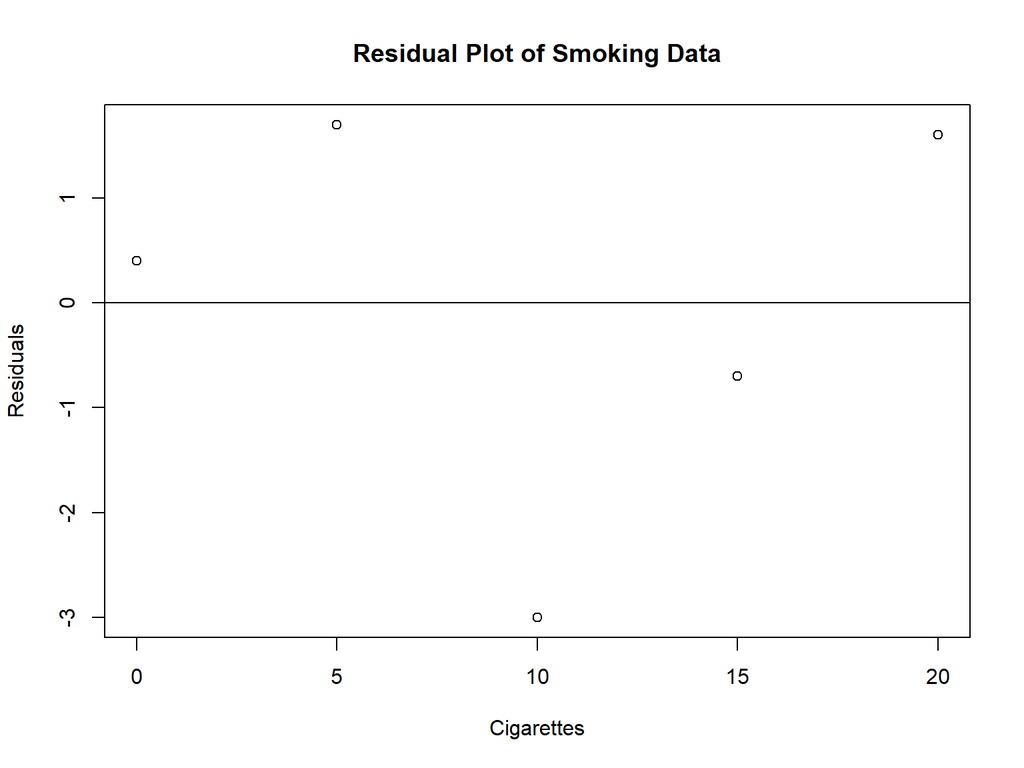

```r
# Ploting
plot(smoking$cigarettes, smoke_regression.resid,
ylab="Residuals", xlab="Cigarettes",
main="Residual Plot of Smoking Data")
abline(0, 0)
```

# Residual Plots

- Plot the residual ($y-\widehat{y}$) against the $x$ value
- A good residual plot, creates a flat line

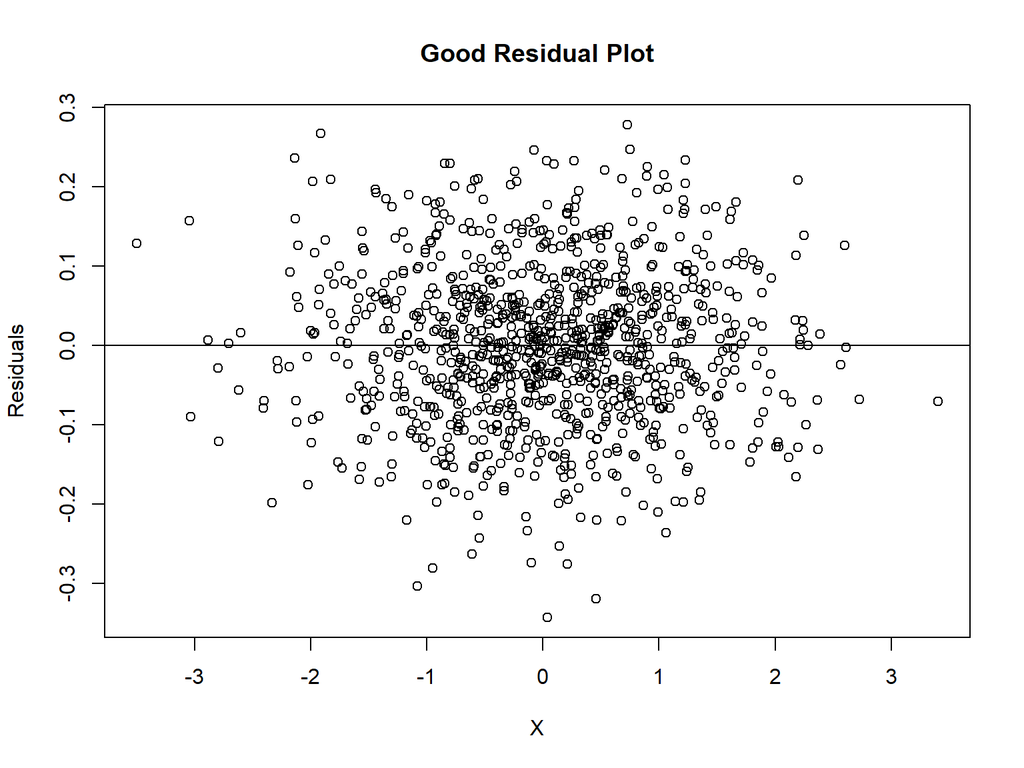

- A concerning residual plot, shows a relationship

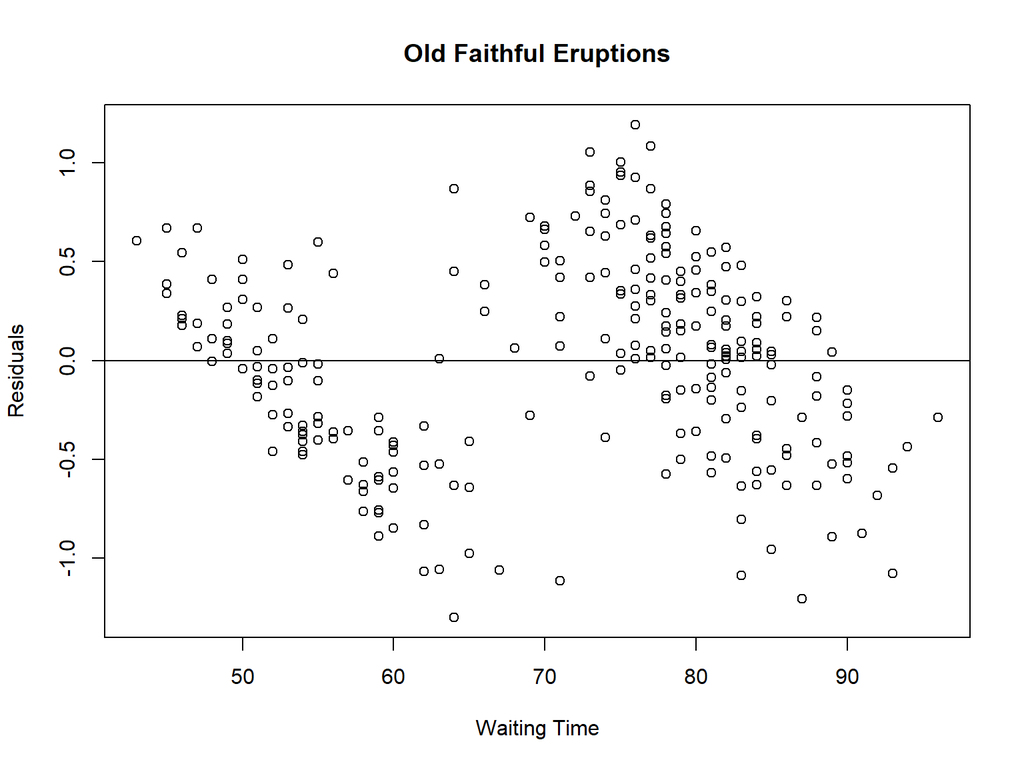

# Beyond two variables

- The residual plot for old faithful eruptions suggests that there are other variables are work.
- Regression can be used to predict $y$ from multiple $x$s.
- However, that is beyond the scope of our class.